# Analysis of Single-Cell RNA-seq - Session 3

Emily V Chambers

Last modified: 13 Dec 2022

# Introduction

To re-cap - we have obtained our raw counts matrices from GEO (or cellranger). We have performed QC and subset the data according to the QC plots we generated. We have normalised the data, selected the most variable features and scaled - regressing out unwanted sources of variation.

In the next part of the course we are going to explore differentially expressed genes between clusters and assigning cluster identity.

## Learning Objectives

- Find differentially expressed genes using `FindMarkers()` and `FindAllMarkers()`.
- Use the biocondictor human annotation package `org.Hs.eg.db` to add some more futher annotation to our marker genes.
- Assign cluster identity using canonical marker genes
- Carry out a simple pathway analysis

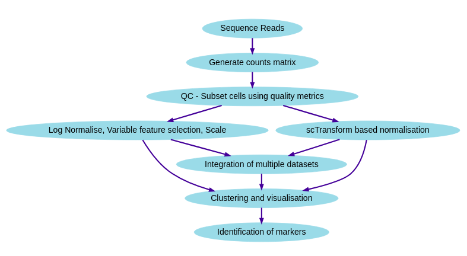

Firstly, we will load up the packages we will needfor this part of the course.

```r
library(Seurat, quietly = T)
library(tidyverse, quietly = T)
library(org.Hs.eg.db, quietly = T)
```

And then we can load up the R objects we have used in the previous sessions.

```r
seurat <- readRDS("Robjects/seurat_integrated.RDS")
```

We can recap our clustering by taking a look at the `DimPLot`

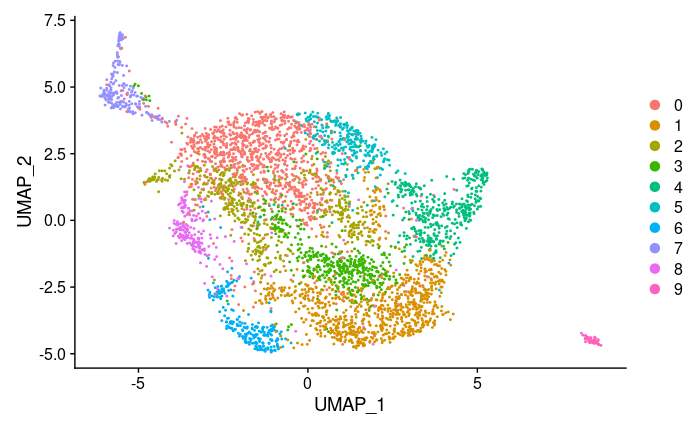

# Find differentially expressed genes

Our next objective is to start assigning some **biological meaning** to our data. We have some nice clusters but no clue yet what cell groups out clusters contain.

In Seurat we can find the top differentially expressed genes, or markers, within each cluster. The function `FindMarkers()` handles most of the differential expression testing within the Seurat package and finds marker genes within a particular cluster. As a default, Seurat performs differential expression based on the non-parameteric Wilcoxon rank sum test but other methods are available within the function.

To start with we can find all the differentially expressed genes in cluster 8 compared to every other cluster. The min.pct argument requires a gene to be detected at a minimum percentage of cells.

```r
# We make sure the default assay is set back to "RNA" to use the original counts for DE analysis.
DefaultAssay(seurat) <- "RNA"
```

```r
cluster8.markers <- FindMarkers(seurat, ident.1 = 8, min.pct  = 0.25, verbose = F)
cluster8.markers %>% head
```

|  | p_val | avg_log2FC | pct.1 | pct.2 | p_val_adj |
| --- | --- | --- | --- | --- | --- |
| C1orf56 | 7.659397e-99 | 1.0294830 | 0.648 | 0.136 | 1.113600e-94 |
| HNRNPH1 | 2.429457e-66 | 0.9393532 | 0.864 | 0.470 | 3.532187e-62 |
| CDC42SE1 | 5.422196e-56 | 0.8612430 | 0.593 | 0.194 | 7.883331e-52 |
| PHKG1 | 3.095624e-41 | 0.4419249 | 0.256 | 0.043 | 4.500728e-37 |
| SET | 1.620426e-40 | 0.5585715 | 0.834 | 0.653 | 2.355938e-36 |
| LRRC75A | 2.555030e-32 | 0.4513549 | 0.276 | 0.063 | 3.714758e-28 |

A little bit of table manipulation in `dplyr` makes the markers easier to view…

```r
cluster8.markers  %>% dplyr::select(avg_log2FC, p_val, p_val_adj) %>%slice_max(n = 5, order_by = avg_log2FC)
```

|  | avg_log2FC | p_val | p_val_adj |
| --- | --- | --- | --- |
| C1orf56 | 1.0294830 | 7.659397e-99 | 1.113600e-94 |
| HNRNPH1 | 0.9393532 | 2.429457e-66 | 3.532187e-62 |
| CDC42SE1 | 0.8612430 | 5.422196e-56 | 7.883331e-52 |
| CTNNB1 | 0.6191626 | 2.511077e-29 | 3.650855e-25 |
| SET | 0.5585715 | 1.620426e-40 | 2.355938e-36 |

To check our DE findings, we can visualize expression of a particular gene of interest across all clusters using the `VlnPlot()` function. This shows expression of a gene (or genes) of interest across all clusters.

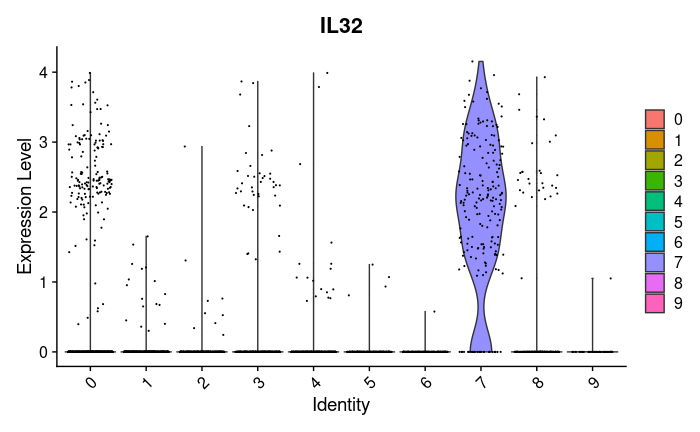

```r
VlnPlot(seurat, features = "IL32")
```

We can also check which cells express out gene of interest on the UMAP image using `FeaturePlot`

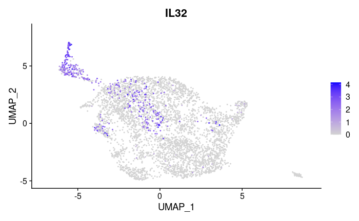

```r
FeaturePlot(seurat, features = "IL32")
```

Perhaps we are most interested in the differentially expressed genes between clusters 1 and 3

```r
cluster1.markers <- FindMarkers(seurat, ident.1 = 1, ident.2 = 3, min.pct = 0.25, verbose = F)
cluster1.markers %>% head()
```

|  | p_val | avg_log2FC | pct.1 | pct.2 | p_val_adj |
| --- | --- | --- | --- | --- | --- |
| IGLL1 | 5.475317e-81 | 0.9844581 | 0.767 | 0.300 | 7.960564e-77 |
| CD24 | 7.789457e-50 | 0.4938598 | 0.908 | 0.634 | 1.132509e-45 |
| LTB | 6.379247e-49 | -0.4833985 | 0.706 | 0.892 | 9.274787e-45 |
| CMTM8 | 1.134617e-38 | 0.5861869 | 0.617 | 0.274 | 1.649619e-34 |
| HMGB1 | 5.228191e-38 | 0.2623193 | 0.991 | 0.922 | 7.601266e-34 |
| CD79B | 2.214502e-36 | 0.4936164 | 0.837 | 0.595 | 3.219665e-32 |

… or the DE genes between clusters 1 and 3 and 4?

```r
cluster1.markers <- FindMarkers(seurat, ident.1 = 1, ident.2 = c(3,4), min.pct = 0.25, verbose = F)
cluster1.markers %>% head()
```

|  | p_val | avg_log2FC | pct.1 | pct.2 | p_val_adj |
| --- | --- | --- | --- | --- | --- |
| IGLL1 | 1.798082e-135 | 1.0728006 | 0.767 | 0.261 | 2.614232e-131 |
| CD24 | 1.524823e-79 | 0.5582246 | 0.908 | 0.568 | 2.216940e-75 |
| CMTM8 | 5.900440e-69 | 0.6467517 | 0.617 | 0.237 | 8.578650e-65 |
| CYBA | 4.688702e-67 | -0.2930166 | 0.875 | 0.941 | 6.816904e-63 |
| CD79B | 1.768335e-66 | 0.5783914 | 0.837 | 0.542 | 2.570983e-62 |
| SOX4 | 7.312283e-60 | 0.4462609 | 0.957 | 0.691 | 1.063133e-55 |

Usually, we are wanting to find the most differentially expressed genes in each cluster across the whole dataset. For this we use `FindAllMarkers`. This time we will only report the positively expressed markers with a minimum log fold change of 0.25.

```r
markers <- FindAllMarkers(seurat, only.pos = TRUE, min.pct = 0.25, logfc.threshold = 0.25, verbose = F)

markers %>%
  dplyr::select(gene, cluster, avg_log2FC, p_val, p_val_adj) %>%
    group_by(cluster) %>%
    slice_max(n = 5, order_by = avg_log2FC)
```

| gene | cluster | avg_log2FC | p_val | p_val_adj |
| --- | --- | --- | --- | --- |
| NBEAL1 | 0 | 0.3128806 | 5.361161e-46 | 7.794592e-42 |
| ZNF90 | 0 | 0.2898112 | 3.115110e-25 | 4.529058e-21 |
| DONSON | 0 | 0.2768148 | 1.510529e-14 | 2.196158e-10 |
| SNHG25 | 0 | 0.2675584 | 2.113025e-12 | 3.072126e-08 |
| RGS10 | 0 | 0.2667147 | 1.825266e-19 | 2.653754e-15 |
| IGLL1 | 1 | 0.9821108 | 3.156318e-218 | 4.588971e-214 |
| CD79B | 1 | 0.6737136 | 2.113736e-138 | 3.073161e-134 |
| ARPP21 | 1 | 0.5961405 | 1.330883e-136 | 1.934971e-132 |
| CMTM8 | 1 | 0.5755294 | 1.891215e-102 | 2.749637e-98 |
| CD24 | 1 | 0.5387435 | 7.595417e-117 | 1.104298e-112 |

[output cut: 40 more lines]

## Exercise

- Use `FindMarkers` to find the differentially expressed genes in clusters 1 & 2 vs 8
- Can you use `dplr` to select columns of interest and order them by log fold change?
- Use one of the visualisation tools to look at the expression of one of the top marker genes

```r
#Put exercise work in here :-)
```

# Annotating marker genes

We can use gene databases within R to further annotate our marker genes of interest. The `org.Hs.eg.db` database is a genome wide annotationpackage for human that has many different gene mappings based on Entrez Gene identifiers.

```r
columns(org.Hs.eg.db) # We can use this command to see which data can be pulled from the database
```

```
 [1] "ACCNUM"       "ALIAS"        "ENSEMBL"      "ENSEMBLPROT"  "ENSEMBLTRANS" "ENTREZID"     "ENZYME"       "EVIDENCE"     "EVIDENCEALL"
[10] "GENENAME"     "GENETYPE"     "GO"           "GOALL"        "IPI"          "MAP"          "OMIM"         "ONTOLOGY"     "ONTOLOGYALL"
[19] "PATH"         "PFAM"         "PMID"         "PROSITE"      "REFSEQ"       "SYMBOL"       "UCSCKG"       "UNIPROT"
```

```r
anno <- AnnotationDbi::select(org.Hs.eg.db,keys=rownames(seurat),columns=c("SYMBOL","GENENAME", "ENTREZID"), keytype = "SYMBOL")
# Check it worked!
head(anno)
```

|  | SYMBOL | GENENAME | ENTREZID |
| --- | --- | --- | --- |
| 1 | FO538757.2 | NA | NA |
| 2 | AP006222.2 | NA | NA |
| 3 | RP4-669L17.10 | NA | NA |
| 4 | RP11-206L10.9 | NA | NA |
| 5 | LINC00115 | long intergenic non-protein coding RNA 115 | 79854 |
| 6 | FAM41C | family with sequence similarity 41 member C | 284593 |

Now we can combine our annotation table to our marker genes using `dplyr` and `left_join`

```r
anno_markers <- markers %>%
  dplyr::select(gene, cluster, avg_log2FC, p_val, p_val_adj) %>%
  left_join(anno, by = c("gene" = "SYMBOL"))

anno_markers %>% head()
```

|  | gene | cluster | avg_log2FC | p_val | p_val_adj | GENENAME | ENTREZID |
| --- | --- | --- | --- | --- | --- | --- | --- |
| 1 | NBEAL1 | 0 | 0.3128806 | 5.361161e-46 | 7.794592e-42 | neurobeachin like 1 | 65065 |
| 2 | ZNF90 | 0 | 0.2898112 | 3.115110e-25 | 4.529058e-21 | zinc finger protein 90 | 7643 |
| 3 | RGS10 | 0 | 0.2667147 | 1.825266e-19 | 2.653754e-15 | regulator of G protein signaling 10 | 6001 |
| 4 | DONSON | 0 | 0.2768148 | 1.510529e-14 | 2.196158e-10 | DNA replication fork stabilization factor DONSON | 29980 |
| 5 | SNHG25 | 0 | 0.2675584 | 2.113025e-12 | 3.072126e-08 | small nucleolar RNA host gene 25 | 105376843 |
| 6 | IGLL1 | 1 | 0.9821108 | 3.156318e-218 | 4.588971e-214 | immunoglobulin lambda like polypeptide 1 | 3543 |

```r
NA
```

# Assigning cluster identity

To assign biological meaning to our clusters, we are going to use canonical cell type markers from the paper. These genes are known to be expressed in a particular cell type.

[output not shown]

We can assign these marker genes as a variable

```r
cell_markers <- c("CD34", "MS4A1", "CST3" ,"SPN", "HBA1", "CD3D", "NKG7", "GNLY",  "MZB1")
```

Dot plots allow us to examine particular features or genes of interest across all clusters. Creating a dotplot of the cell type markers lets us assign identity based on their expression.

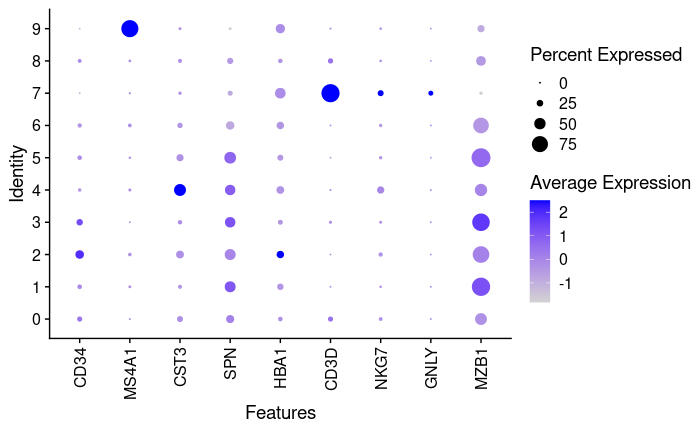

```r
DotPlot(seurat, features = cell_markers) + theme(axis.text.x = element_text(angle = 90, vjust = 0.5, hjust=1))
```

We can then manually create new identities for each cluster as follows.

```r
new.cluster.ids <- c("Variable", "Immature HPC", "B Cells + Erythrocytes", "BMCA", "Monocytes", "Cancer cells", "HPC", "T Cells + NK Cells", "B cells", "CD20+ B Cells")
names(new.cluster.ids) <- levels(seurat)
new.cluster.ids
seurat <- RenameIdents(seurat, new.cluster.ids)
```

[figure not shown]

```r
DimPlot(seurat, reduction = "umap", label = TRUE, pt.size = 0.5) + NoLegend()
```

# GO term and pathway enrichment

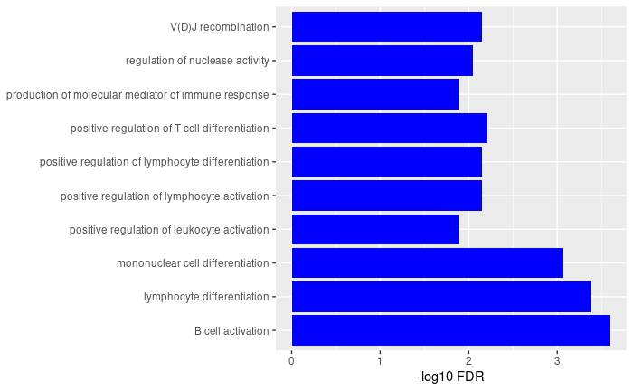